# tp2

Lapu Matthias | Amaël Kreis

2023-02-17

## I. Variation sous-jacente et échantillonnage répété

1. Si X ∼ E(0.5), quelle est la probabilité qu’on observe une valeur supérieure à 3?

2.Simulez un échantillon de taille n = 20 d’un loi de E(0,5), créez un histogramme de votre échantillon et commentez la forme de votre histogramme. Superposer la vrai densité. Quelle est la probabilité empirique qu’on observe une valeur supérieure à 3 ?

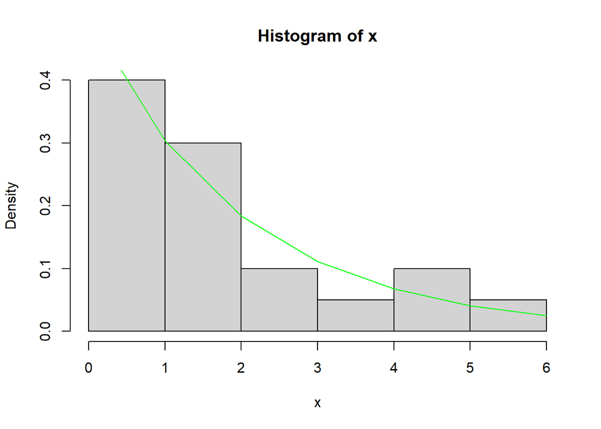

```r
x<-rexp(20,0.5)
hist(x, freq=FALSE)
maxvalue <- ceiling(max(x))
lines(0:maxvalue,dexp(0:maxvalue, 0.5), col="green",)
```

3.Répétez cette opération 5 ou 6 fois et commentez les différences entre les histogrammes que vous obtenez à chaque fois. Utilisez la même limite sur les axes pour faciliter la comparaison. Notez également comment la probabilité empirique qu’on observe une valeur supérieure à 3 change.

4. Augmentez la taille de votre échantillon à 100 et répétez votre expérience. Que remarquez-vous?

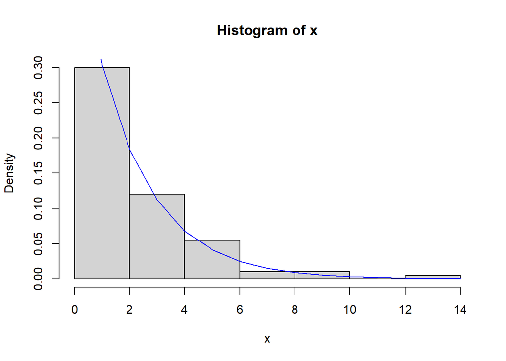

## II. Variabilité aléatoire du maximum de l’échantillon

# 1. Simuler un échantillon de taille n = 10 d’une loi U(−1, 1) et enregistrez le maximum de l’échantillon.

```r
x <- runif(10, -1, 1)
max <- max(x)
```

# 2. Répétez les deux étapes ci-dessus dix fois, en écrivant le maximum de l’échantillon à chaque fois. Commentez la variabilité des valeurs que vous obtenez pour les maxima de votre échantillon.

```r
for (i in 1:10) {
  x <- runif(10, -1, 1)
}
```

# 3. Répétez 100 fois et construisez un histogramme et une boîte à moustaches. Quelle est la loi dumaximum, M = max 1≤i≤n X i où X i ∼ U(−1, 1) (TD1) ? Superposer la densité théoreique sur l’histogramme. Que remarquez-vous ?

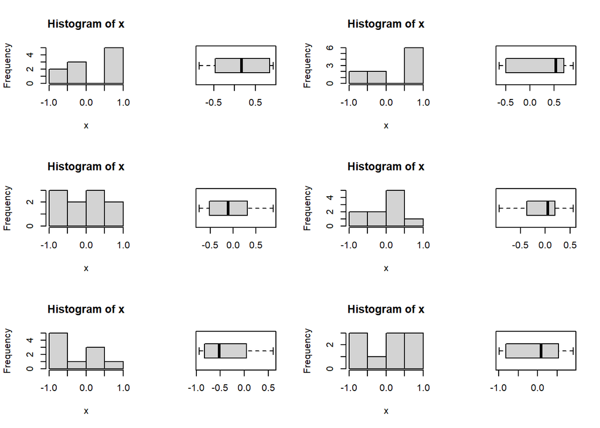

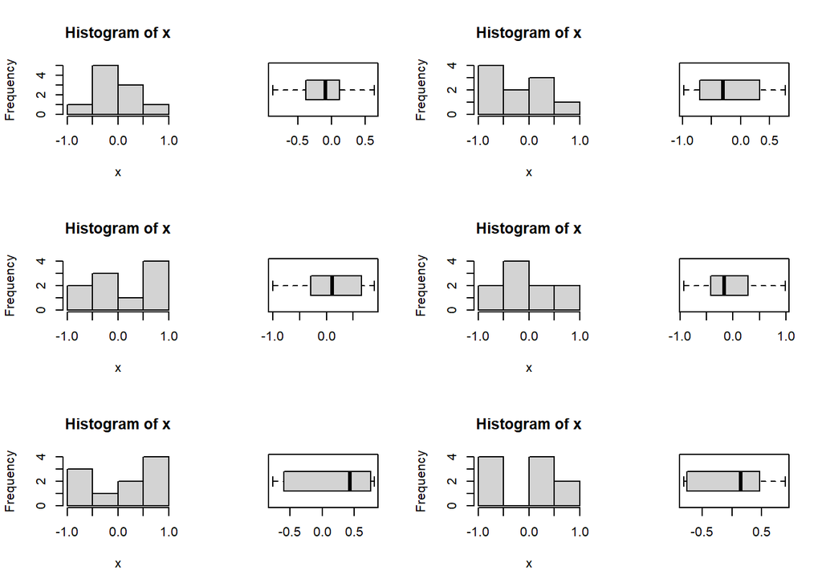

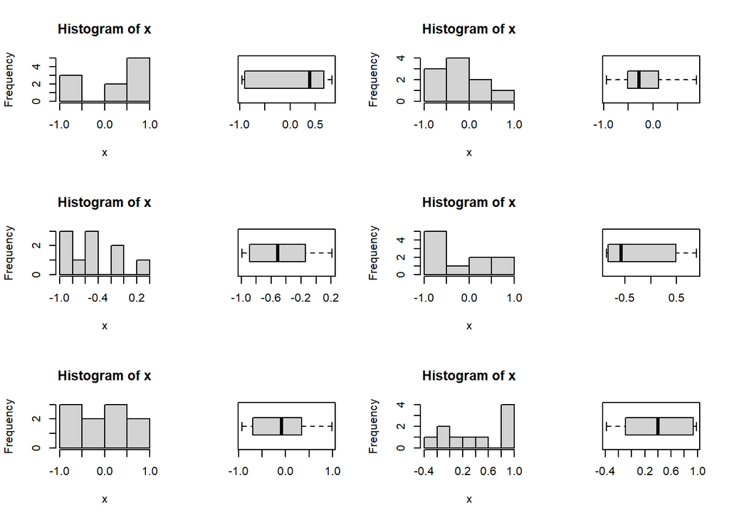

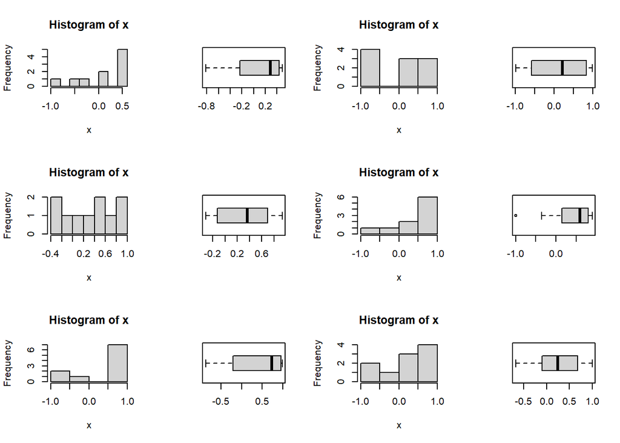

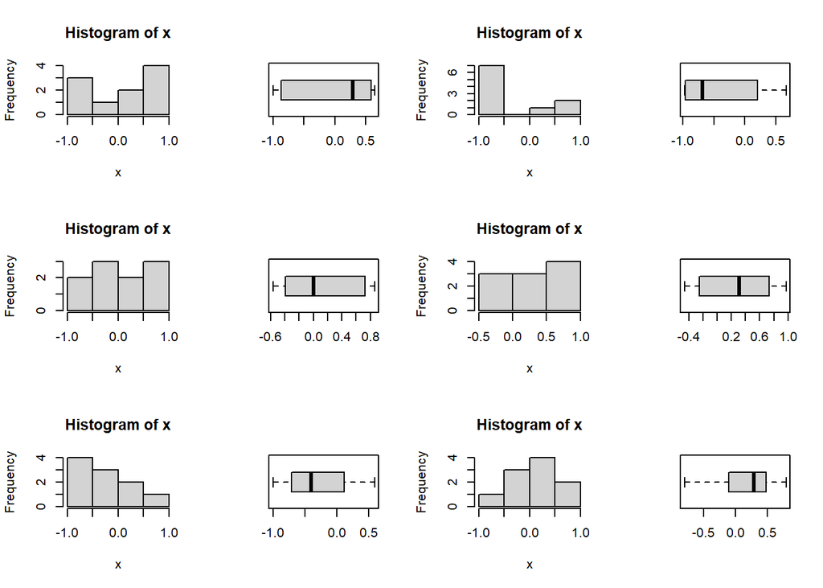

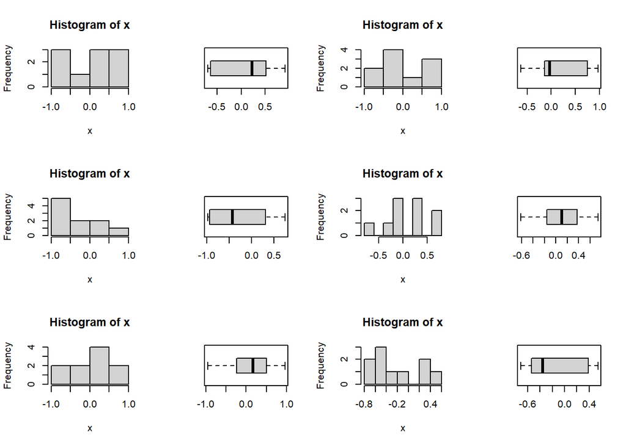

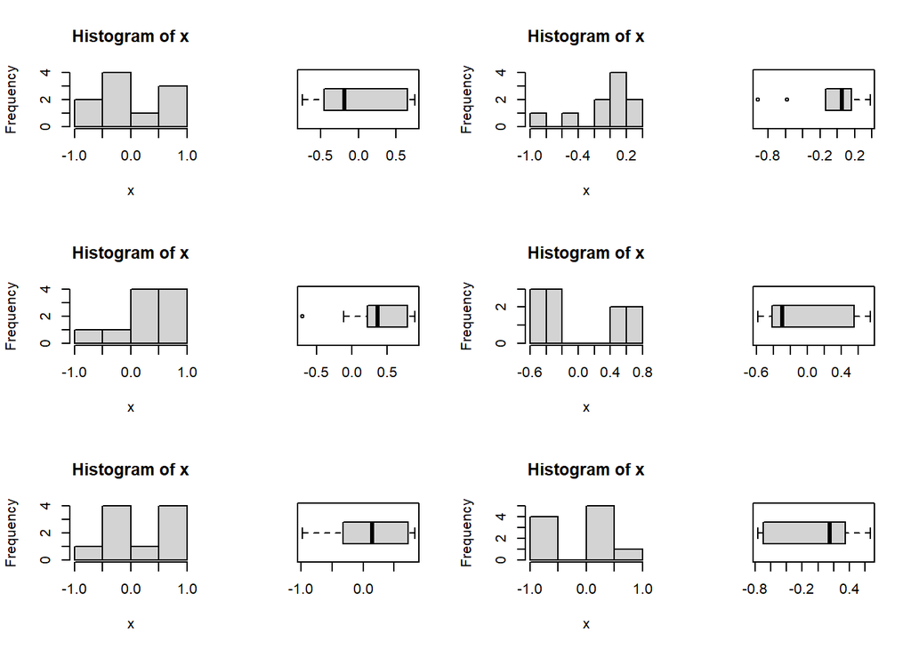

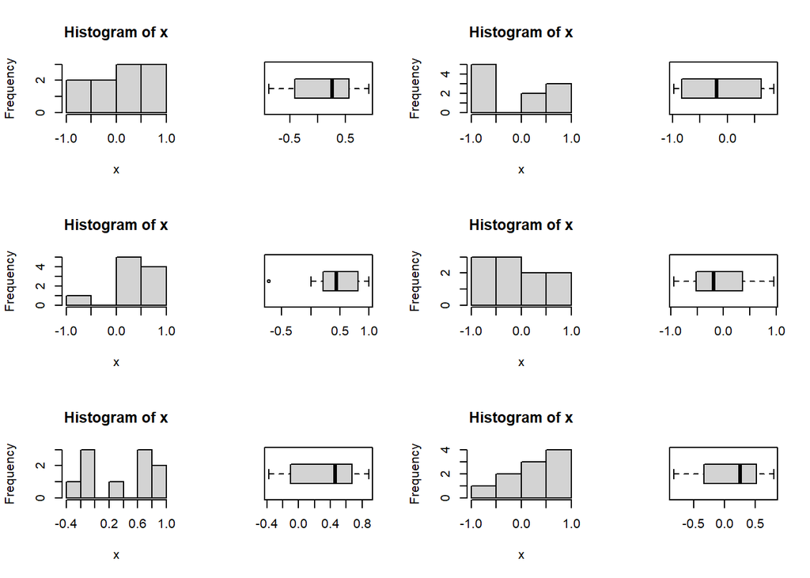

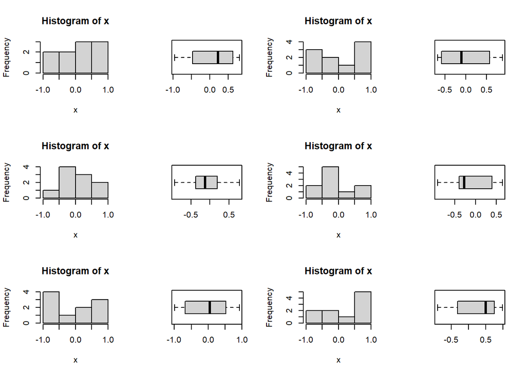

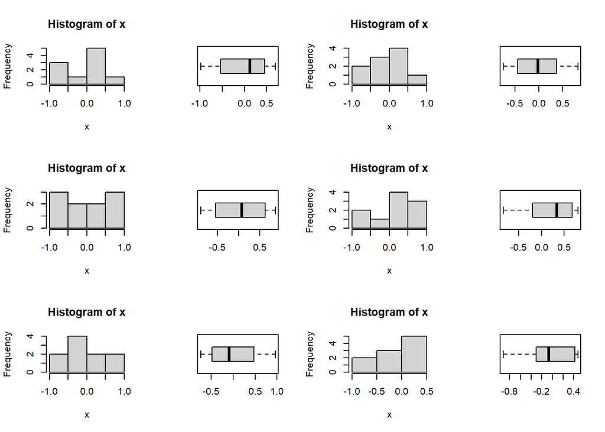

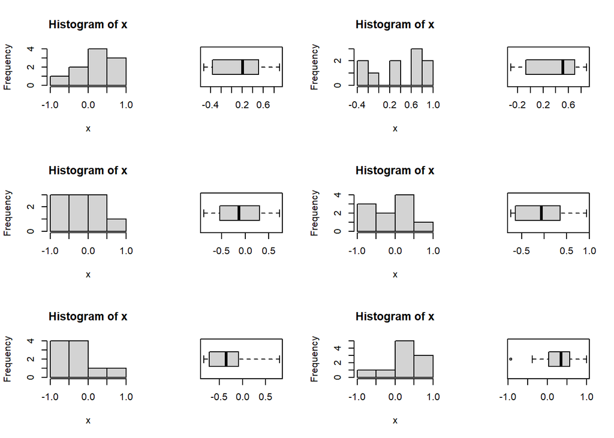

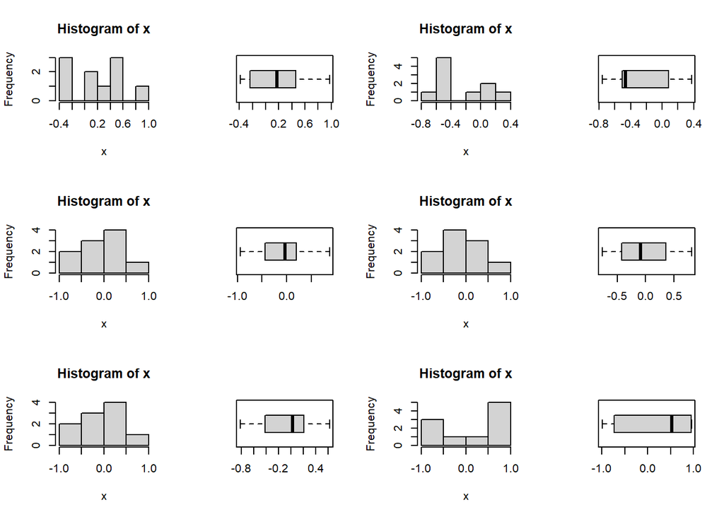

[5 more figures not shown]

```r
par(mfrow=c(3,4))
for (i in 1:100) {
  x <- runif(10, -1, 1)
  hist(x)
  boxplot(x, horizontal = TRUE)
}
```

# 4. Augmentez la taille de votre échantillon à 50 et répétez votre expérience. Que remarquez-vous? Sont-ils proches de la symétrie ?

```r
x <- runif(50, -1, 1)
```

# Moyenne et phénomène de concentration.

1. Supposons que la variance σ2 = V [ψ(X)] < ∞. Donner une borne de cette quantité en utilisant l’inégalité de Bienaymé Chebychev.

On trouve grace à l’inégalité de Bienaymé Chebychev:

$$a^{2}P(|\psi(X) - \theta| \ge a) \le V[\psi(X)]$$

2. En supposant que a ≤ ψ(Xi) ≤ b, donner une borne en utilisant l’inégalité de Hoeffding.

$$On\;a:\;S_{n} = \sum_{k=1}^{n}\psi(X)=n\psi(X)$$

$$P(|S_{n}-E(S_{n})| \ge t) \le
2exp(-\frac{2t^{2}}{\sum_{k=1}^{n}(b-a)^{2}})$$

$$\Leftrightarrow
P(|n\psi(X)-n\theta| \ge t) \le 2exp(-\frac{2t^{2}}{n(b-a)^{2}})$$

$$\Leftrightarrow
P(|\psi(X)-\theta| \ge u) \le 2exp(-\frac{2nu^{2}}{(b-a)^{2}})$$

## Théorème Central Limite et Estimation Monte Carlo

1. Vérifier que l’espérance théorique d’une loi de Pareto est E [X] = αa/α−1.

$$P(X\le t)= (1-\left( \frac{a}{t} \right)^{\alpha}) , \;avec \;x \ge a$$

Donc

$$E(X) = \int_{0}^{+\infty}1-P(X\le t)dt = \int_{0}^{+\infty}P(X\gt t)dt$$

$$=a+a^{\alpha}\int_{a}^{+\infty}\frac{1}{t^{\alpha}}dt=a +
\frac{a}{\alpha -1} =\frac{\alpha a}{\alpha -1}$$

```
## [1] "Moyenne empirique n = 5"
```

```
## [1] 1.478274 1.484586 1.467959 1.461481 1.572638
```

```
## [1] "Moyenne empirique n = 30"
```

```
##  [1] 1.550287 1.535836 1.567102 1.529006 1.464565 1.516993 1.493739 1.490558
##  [9] 1.509205 1.475736 1.476739 1.510254 1.494126 1.499953 1.488642 1.519584
## [17] 1.535510 1.480159 1.485327 1.502363 1.544902 1.504999 1.519937 1.472056
## [25] 1.528689 1.495098 1.531791 1.544564 1.459693 1.517200
```

```
## [1] "Moyenne empirique n = 100"
```

```
##   [1] 1.490047 1.490706 1.466831 1.488355 1.463509 1.571930 1.495803 1.491082
##   [9] 1.542307 1.494886 1.480271 1.480647 1.493733 1.452822 1.453587 1.474481
##  [17] 1.528814 1.493108 1.480284 1.460832 1.497879 1.536727 1.487840 1.454195
##  [25] 1.494735 1.487887 1.527341 1.486859 1.527824 1.495562 1.477727 1.537531
##  [33] 1.512433 1.514830 1.507694 1.524637 1.496334 1.440130 1.500660 1.482956
##  [41] 1.439664 1.484932 1.490374 1.517992 1.498280 1.489181 1.510397 1.531004
##  [49] 1.501468 1.473986 1.469622 1.532189 1.526242 1.501337 1.497090 1.541735
##  [57] 1.493126 1.510127 1.503630 1.461261 1.487360 1.508337 1.495829 1.483868
##  [65] 1.504771 1.499856 1.520177 1.505402 1.487992 1.499219 1.523663 1.509541
##  [73] 1.486374 1.520266 1.485061 1.520551 1.549223 1.481575 1.493625 1.536545
##  [81] 1.493224 1.486804 1.507797 1.527854 1.481051 1.518113 1.481229 1.487874
##  [89] 1.490252 1.497288 1.484879 1.496753 1.500405 1.526316 1.497966 1.485307
##  [97] 1.514668 1.560500 1.506141 1.541021
```

```
## [1] "Variance empirique n = 5"
```

```
## [1] 0.002185295 0.002203996 0.002154903 0.002135927 0.002473190
```

```
## [1] "Variance empirique n = 30"
```

```
##  [1] 0.002403390 0.002358793 0.002455808 0.002337860 0.002144952 0.002301269
##  [7] 0.002231258 0.002221762 0.002277701 0.002177797 0.002180757 0.002280866
## [13] 0.002232411 0.002249859 0.002216055 0.002309137 0.002357791 0.002190871
## [19] 0.002206196 0.002257095 0.002386722 0.002265022 0.002310209 0.002166948
## [25] 0.002336889 0.002235318 0.002346383 0.002385677 0.002130704 0.002301894
```

```
## [1] "Variance empirique n = 100"
```

```
##   [1] 0.002220239 0.002222203 0.002151593 0.002215201 0.002141859 0.002470965
##   [7] 0.002237425 0.002223325 0.002378712 0.002234683 0.002191202 0.002192315
##  [13] 0.002231238 0.002110692 0.002112914 0.002174096 0.002337273 0.002229371
##  [19] 0.002191241 0.002134030 0.002243640 0.002361531 0.002213669 0.002114682
##  [25] 0.002234233 0.002213809 0.002332771 0.002210749 0.002334247 0.002236705
##  [31] 0.002183677 0.002364000 0.002287454 0.002294709 0.002273143 0.002324519
##  [37] 0.002239016 0.002073974 0.002251981 0.002199160 0.002072633 0.002205023
##  [43] 0.002221214 0.002304301 0.002244842 0.002217660 0.002281300 0.002343974
##  [49] 0.002254405 0.002172634 0.002159790 0.002347604 0.002329416 0.002254014
##  [55] 0.002241278 0.002376948 0.002229426 0.002280485 0.002260903 0.002135285
##  [61] 0.002212239 0.002275079 0.002237504 0.002201863 0.002264335 0.002249568
##  [67] 0.002310939 0.002266234 0.002214121 0.002247658 0.002321550 0.002278713
##  [73] 0.002209307 0.002311208 0.002205406 0.002312074 0.002400092 0.002195065
##  [79] 0.002230917 0.002360971 0.002229718 0.002210585 0.002273453 0.002334339
##  [85] 0.002193512 0.002304666 0.002194039 0.002213770 0.002220851 0.002241871
##  [91] 0.002204866 0.002240270 0.002251216 0.002329642 0.002243902 0.002206136
##  [97] 0.002294219 0.002435161 0.002268461 0.002374747
```

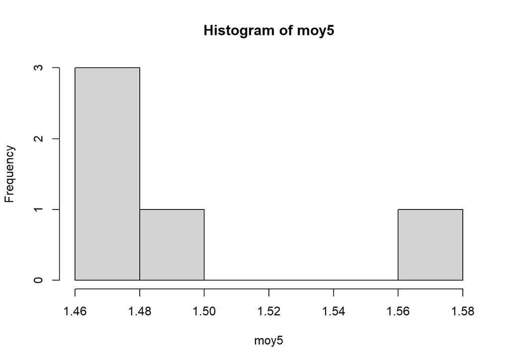

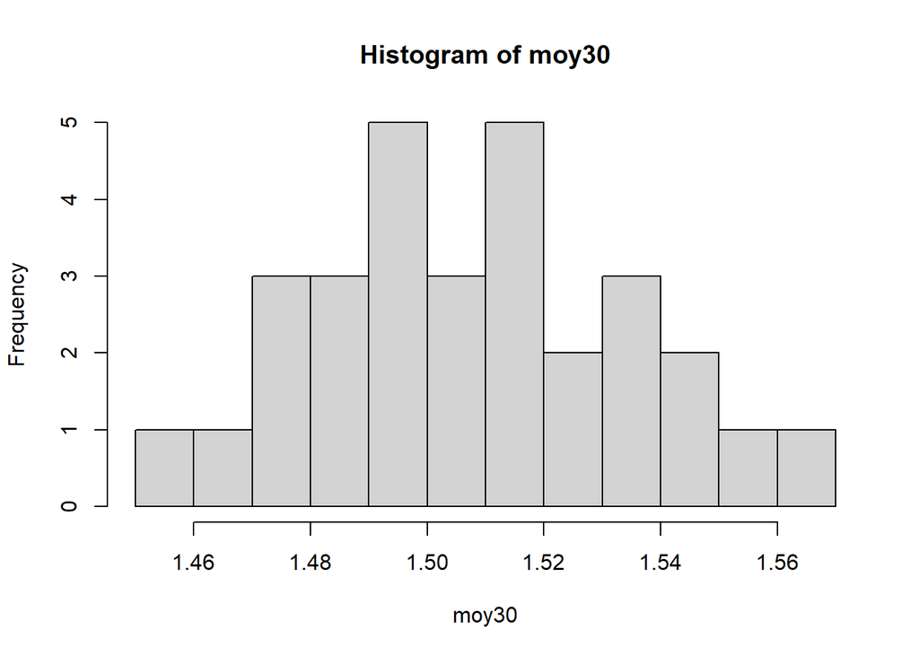

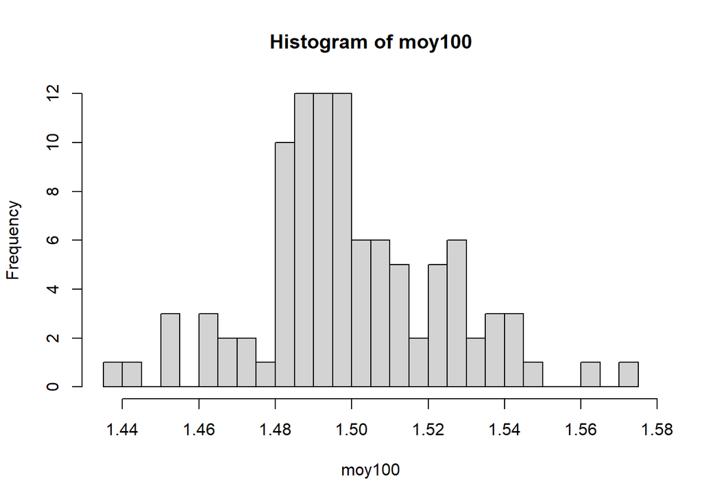

4. A l’aide d’une renormalisation adéquate (an, bn), montrer que Un,i = ¯Xn,i−an/ bn a une loi que vous pouvez approchez. Comparez histogramme de les moyennes empiriques normalisées, Un,i, et distribution théorique approchée. Quelle est l’influence de la taille de l’échantillon n sur la qualité de cette approximation?

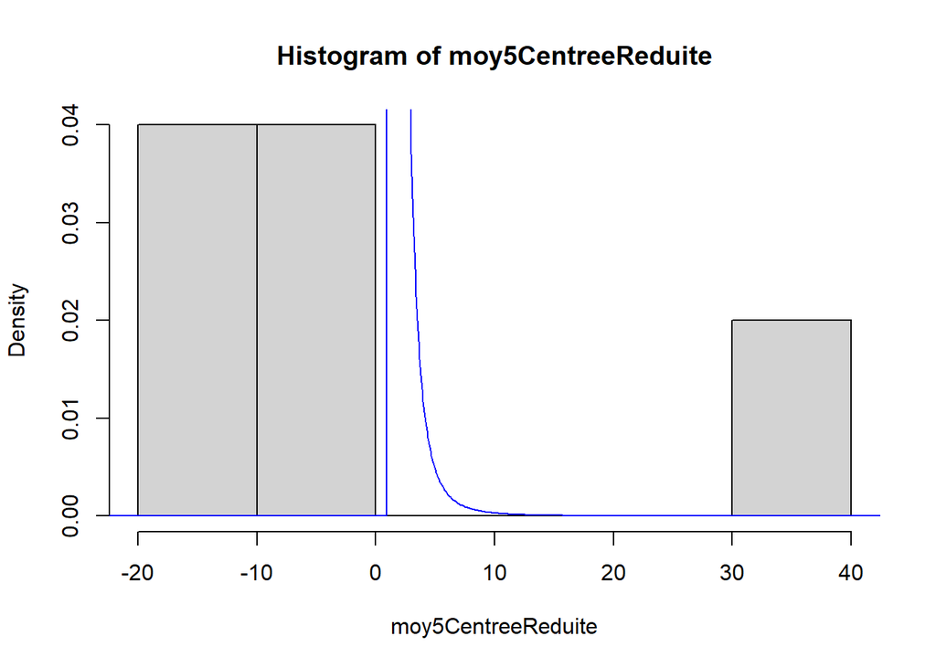

```r
moy5CentreeReduite <- (moy5-mean(moy5))/mean(moy5^2/1000)
moy30CentreeReduite <- (moy30-mean(moy30))/mean(moy30^2/1000)
moy100CentreeReduite <- (moy100-mean(moy100))/mean(moy100^2/1000)

hist(moy5CentreeReduite,freq=FALSE)
lines(seq(-50,50,by=0.1),dpareto(seq(-50,50,by=0.1),1,3),col = "blue")
```

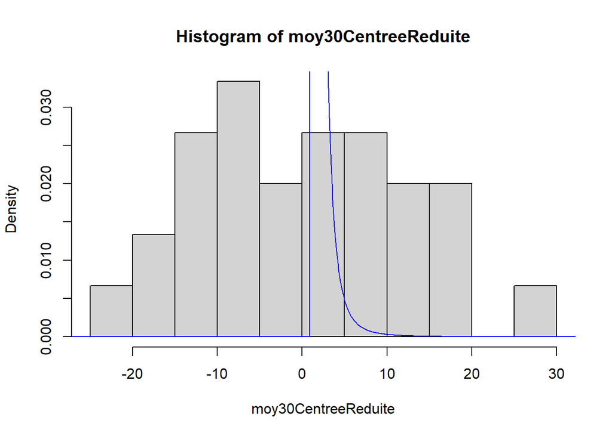

```r
hist(moy30CentreeReduite,freq=FALSE,breaks = 10)
lines(seq(-50,50,by=0.1),dpareto(seq(-50,50,by=0.1),1,3),col = "blue")
```

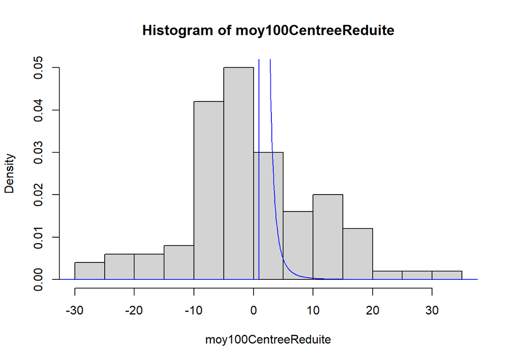

```r
hist(moy100CentreeReduite,freq=FALSE,breaks = 20)
lines(seq(-50,50,by=0.1),dpareto(seq(-50,50,by=0.1),1,3),col = "blue")
```

## Quand le théorème de central limite ne s’applique pas

1. Simuler un échantillon de taille n = 20 d’une loi de C(2) et calculer la moyenne empirique ¯Xn.

Moyenne empirique:

```
## [1] 3.13144
```

2. Faites varier la taille de l’échantillon n = 20, 100, 1000 et 10000. Qu’en déduire ?

```
## [1] -1.360177
```

```
## [1] 1.393646
```

```
## [1] 13.008
```

```
## [1] 3.887151
```